# Tech 3, Main Analyses: THE CROWDSOURCED REPLICATION INITIATIVE (CRI)

## THE CROWDSOURCED REPLICATION INITIATIVE (CRI)

[“Executive Report”](https://osf.io/preprints/socarxiv/6j9qb/) contains details of the project.

Principal Investigators: Nate Breznau

Eike Mark Rinke

Alexander Wuttke

Code Compiled by Nate Breznau, breznau.nate@gmail.com

Hung Nguyen, hunghvnguyen@gmail.com

### Contents

1. Data Prep - Merge results, qualitative model specs and research characteristics
2. Explain variance of AMEs
3. Generate specification curves

### Special Package

We load the rdfanalysis package designed by [Joachim Gassen](https://joachim-gassen.github.io/rdfanalysis/) to generate specification curves.

### Load Data

These datasets were worked up from the file CRI_Data_Prep_1.Rmd.

cri = numerical values cri_str = string values cri_team = team-level data (by conclusion)

```r
cri <- read.csv(file = wdir("cri.csv"), header = T)
cri_str <- read.csv(file = wdir("cri_str.csv"), header = T)
cri_team <- read.csv(file = wdir("cri_team.csv"), header = T)
```

### Descriptives

#### Model Level

```r
sum1 <- summarise_at(cri, vars(AME, AME_Z, p, Hsup, Hrej, Hno, Jobs:ChangeFlow, w1985:w2016, countries, dichotomize,  main_IV_as_control, twowayfe, mlm_any, cluster_any, inv_weight, team_size, stata, r, spss, mplus, mlwin, total_score, stat, belief, topic), funs(mean), na.rm = T)

sum1.1 <- summarise_at(cri,vars(AME, AME_Z, p, Hsup, Hrej, Hno, Jobs:ChangeFlow, w1985:w2016, countries, dichotomize,  main_IV_as_control, twowayfe, mlm_any, cluster_any, inv_weight, team_size, stata, r, spss, mplus, mlwin, total_score, stat, belief, topic), funs(sd), na.rm = T)

# need to fix to get accurate N counts at some point
sum2 <- summarise_at(cri, vars(AME, AME_Z, p, Hsup, Hrej, Hno, Jobs:ChangeFlow, w1985:w2016, countries, dichotomize,  main_IV_as_control, twowayfe, mlm_any, cluster_any, inv_weight, team_size, stata, r, spss, mplus, mlwin, total_score, stat, belief, topic), funs(n()))

sum3 <- summarise_at(cri, vars(AME, AME_Z, p, Hsup, Hrej, Hno, Jobs:ChangeFlow, w1985:w2016, countries, dichotomize,  main_IV_as_control, twowayfe, mlm_any, cluster_any, inv_weight, team_size, stata, r, spss, mplus, mlwin, total_score, stat, belief, topic), funs(min), na.rm = T)

sum4 <- summarise_at(cri, vars(AME, AME_Z, p, Hsup, Hrej, Hno, Jobs:ChangeFlow, w1985:w2016, countries, dichotomize,  main_IV_as_control, twowayfe, mlm_any, cluster_any, inv_weight, team_size, stata, r, spss, mplus, mlwin, total_score, stat, belief, topic), funs(max), na.rm = T)

sum1[2,] <- c("AME","AME, beta","p-value","Support Hypothesis", "Reject Hypothesis", "Not testable Hypothesis", "DV: Jobs", "DV: Unemp", "DV: Income Diffs","DV: Old Age", "Dv: Housing", "DV: Health care", "DV: Constructed Scale", "Test IV: Stock of Immigrants", "Test IV: Flow of Immigrants", "Test IV: Change in Flow", "ISSP Wave: 1985", "ISSP Wave: 1990", "ISSP Wave: 1996", "ISSP Wave: 2006", "ISSP Wave: 2016", "# of countries used", "Dichotomized DV", "Both Test IVs included","Two-Way FEs (year & country dummies", "Used a Multilevel Model", "Used any form of SE clutering","Number of Models (by team)","Team size","Software: Stata","software: R","Software: SPSS","Software: Mplus","software: MLwin","Subjective model score","Statistics skills (by team)","Belief that Hypothesis is true (by team)","Interst in the research topic (by team)")

cri_sum <- rbind(sum1, sum1.1, sum2, sum3, sum4)

cri_sum <- as.data.frame(t(cri_sum))

colnames(cri_sum) <- c("mean","variable", "sd","N","min","max")

cri_sum <- select(cri_sum, variable, mean, everything())

cri_sum$mean <- round(as.numeric(cri_sum$mean), 4)
cri_sum$sd <- round(as.numeric(cri_sum$sd), 4)
cri_sum$min <- round(as.numeric(cri_sum$min), 4)
cri_sum$max <- round(as.numeric(cri_sum$max), 4)

t1 <- kable(cri_sum, row.names = F)

kable_styling(t1)
```

| variable | mean | sd | N | min | max |
| --- | --- | --- | --- | --- | --- |
| AME | 0.0014 | 0.1837 | 1309 | -1.3538 | 2.4700 |
| AME, beta | 0.0001 | 0.0725 | 1309 | -0.5700 | 1.3000 |
| p-value | 0.2924 | 0.3133 | 1309 | 0.0000 | 1.0000 |
| Support Hypothesis | 0.2185 | 0.4134 | 1309 | 0.0000 | 1.0000 |
| Reject Hypothesis | 0.6875 | 0.4637 | 1309 | 0.0000 | 1.0000 |
| Not testable Hypothesis | 0.0940 | 0.2919 | 1309 | 0.0000 | 1.0000 |
| DV: Jobs | 0.2918 | 0.4548 | 1309 | 0.0000 | 1.0000 |
| DV: Unemp | 0.2949 | 0.4562 | 1309 | 0.0000 | 1.0000 |
| DV: Income Diffs | 0.2949 | 0.4562 | 1309 | 0.0000 | 1.0000 |
| DV: Old Age | 0.2949 | 0.4562 | 1309 | 0.0000 | 1.0000 |
| Dv: Housing | 0.2040 | 0.4031 | 1309 | 0.0000 | 1.0000 |
| DV: Health care | 0.2070 | 0.4053 | 1309 | 0.0000 | 1.0000 |
| DV: Constructed Scale | 0.1490 | 0.3562 | 1309 | 0.0000 | 1.0000 |
| Test IV: Stock of Immigrants | 0.4958 | 0.5002 | 1309 | 0.0000 | 1.0000 |
| Test IV: Flow of Immigrants | 0.4714 | 0.4994 | 1309 | 0.0000 | 1.0000 |
| Test IV: Change in Flow | 0.0328 | 0.1783 | 1309 | 0.0000 | 1.0000 |
| ISSP Wave: 1985 | 0.0367 | 0.1880 | 1309 | 0.0000 | 1.0000 |
| ISSP Wave: 1990 | 0.0565 | 0.2310 | 1309 | 0.0000 | 1.0000 |
| ISSP Wave: 1996 | 0.7739 | 0.4185 | 1309 | 0.0000 | 1.0000 |
| ISSP Wave: 2006 | 0.9481 | 0.2220 | 1309 | 0.0000 | 1.0000 |
| ISSP Wave: 2016 | 0.6119 | 0.4875 | 1309 | 0.0000 | 1.0000 |
| # of countries used | 16.7678 | 5.9260 | 1309 | 1.0000 | 31.0000 |
| Dichotomized DV | 0.6112 | 0.4877 | 1309 | 0.0000 | 1.0000 |
| Both Test IVs included | 0.3300 | 0.4704 | 1309 | 0.0000 | 1.0000 |
| Two-Way FEs (year & country dummies | 0.4736 | 0.4995 | 1309 | 0.0000 | 1.0000 |
| Used a Multilevel Model | 0.5225 | 0.4997 | 1309 | 0.0000 | 1.0000 |
| Used any form of SE clutering | 0.2147 | 0.4107 | 1309 | 0.0000 | 1.0000 |
| Number of Models (by team) | 39.2796 | 32.0974 | 1309 | 1.0000 | 112.0000 |
| Team size | 2.2353 | 0.7769 | 1309 | 1.0000 | 3.0000 |
| Software: Stata | 0.7196 | 0.4494 | 1309 | 0.0000 | 1.0000 |
| software: R | 0.1933 | 0.3950 | 1309 | 0.0000 | 1.0000 |
| Software: SPSS | 0.0153 | 0.1227 | 1309 | 0.0000 | 1.0000 |
| Software: Mplus | 0.0565 | 0.2310 | 1309 | 0.0000 | 1.0000 |
| software: MLwin | 0.0244 | 0.1545 | 1309 | 0.0000 | 1.0000 |
| Subjective model score | 0.4429 | 0.1136 | 1309 | 0.1489 | 0.7289 |
| Statistics skills (by team) | -0.0467 | 0.4226 | 1309 | -1.4479 | 0.7864 |
| Belief that Hypothesis is true (by team) | -0.0786 | 0.5436 | 1309 | -1.4579 | 1.0180 |
| Interst in the research topic (by team) | -0.0779 | 0.4431 | 1309 | -0.6723 | 1.4488 |

```r
NA
```

#### Team-Result Level

some teams reported two results split along the type of test variable, for these teams there are two cases in this table (89 cases for 73 teams plus the B&F original)

```r
sum1 <- summarise_at(cri_team, vars(AME, AME_Z, p, Hsup, Hrej, Hno, Jobs:ChangeFlow, w1985:w2016, countries, dichotomize,  main_IV_as_control, twowayfe, mlm_any, cluster_any, inv_weight, team_size, stata, r, spss, mplus, mlwin, total_score, stat, belief, topic), funs(mean), na.rm = T)

sum1.1 <- summarise_at(cri_team, vars(AME, AME_Z, p, Hsup, Hrej, Hno, Jobs:ChangeFlow, w1985:w2016, countries, dichotomize,  main_IV_as_control, twowayfe, mlm_any, cluster_any, inv_weight, team_size, stata, r, spss, mplus, mlwin, total_score, stat, belief, topic), funs(sd), na.rm = T)

# need to fix to get accurate N counts at some point
sum2 <- summarise_at(cri_team, vars(AME, AME_Z, p, Hsup, Hrej, Hno, Jobs:ChangeFlow, w1985:w2016, countries, dichotomize,  main_IV_as_control, twowayfe, mlm_any, cluster_any, inv_weight, team_size, stata, r, spss, mplus, mlwin, total_score, stat, belief, topic), funs(n()))

sum3 <- summarise_at(cri_team, vars(AME, AME_Z, p, Hsup, Hrej, Hno, Jobs:ChangeFlow, w1985:w2016, countries, dichotomize,  main_IV_as_control, twowayfe, mlm_any, cluster_any, inv_weight, team_size, stata, r, spss, mplus, mlwin, total_score, stat, belief, topic), funs(min), na.rm = T)

sum4 <- summarise_at(cri_team, vars(AME, AME_Z, p, Hsup, Hrej, Hno, Jobs:ChangeFlow, w1985:w2016, countries, dichotomize,  main_IV_as_control, twowayfe, mlm_any, cluster_any, inv_weight, team_size, stata, r, spss, mplus, mlwin, total_score, stat, belief, topic), funs(max), na.rm = T)

sum1[2,] <- c("AME (team average)","AME, beta (team average)","p-value (team average)","Support Hypothesis", "Reject Hypothesis", "Not testable Hypothesis", "DV: Jobs (team average)", "DV: Unemp (team average)", "DV: Income Diffs (team average)","DV: Old Age (team average)", "Dv: Housing (team average)", "DV: Health care (team average)", "DV: Constructed Scale (team average)", "Test IV: Stock of Immigrants (team average)", "Test IV: Flow of Immigrants (team average)", "Test IV: Change in Flow (team average)", "ISSP Wave: 1985 (team average)", "ISSP Wave: 1990 (team average)", "ISSP Wave: 1996 (team average)", "ISSP Wave: 2006 (team average)", "ISSP Wave: 2016 (team average)", "# of countries used (team average)", "Dichotomized DV (team average)", "Both Test IVs included (team average)","Two-Way FEs (year & country dummies (team average)", "Use a Multilevel Model (team average)", "Any form of SE clutering (team average)","Number of Models ","Team size","Software: Stata","software: R","Software: SPSS","Software: Mplus","software: MLwin","Subjective model score","Statistics skills","Belief that Hypothesis is true","Interst in the research topic")

cri_sum <- rbind(sum1, sum1.1, sum2, sum3, sum4)

cri_sum <- as.data.frame(t(cri_sum))

colnames(cri_sum) <- c("mean","variable", "sd","N","min","max")

cri_sum <- select(cri_sum, variable, mean, everything())

cri_sum$mean <- round(as.numeric(cri_sum$mean), 4)
cri_sum$sd <- round(as.numeric(cri_sum$sd), 4)
cri_sum$min <- round(as.numeric(cri_sum$min), 4)
cri_sum$max <- round(as.numeric(cri_sum$max), 4)

rm(sum1,sum1.1,sum2,sum3,sum4)

t2 <- kable(cri_sum, row.names = F)

kable_styling(t2)
```

| variable | mean | sd | N | min | max |
| --- | --- | --- | --- | --- | --- |
| AME (team average) | -0.0093 | 0.0871 | 89 | -0.3918 | 0.3596 |
| AME, beta (team average) | -0.0048 | 0.0367 | 89 | -0.2018 | 0.1514 |
| p-value (team average) | 0.2382 | 0.1880 | 89 | 0.0000 | 0.7710 |
| Support Hypothesis | 0.2584 | 0.4403 | 89 | 0.0000 | 1.0000 |
| Reject Hypothesis | 0.6180 | 0.4886 | 89 | 0.0000 | 1.0000 |
| Not testable Hypothesis | 0.1236 | 0.3310 | 89 | 0.0000 | 1.0000 |
| DV: Jobs (team average) | 0.4562 | 0.3687 | 89 | 0.0000 | 1.0000 |
| DV: Unemp (team average) | 0.4562 | 0.3687 | 89 | 0.0000 | 1.0000 |
| DV: Income Diffs (team average) | 0.4562 | 0.3687 | 89 | 0.0000 | 1.0000 |
| DV: Old Age (team average) | 0.4562 | 0.3687 | 89 | 0.0000 | 1.0000 |
| Dv: Housing (team average) | 0.2798 | 0.3680 | 89 | 0.0000 | 1.0000 |
| DV: Health care (team average) | 0.2911 | 0.3746 | 89 | 0.0000 | 1.0000 |
| DV: Constructed Scale (team average) | 0.3583 | 0.4736 | 89 | 0.0000 | 1.0000 |
| Test IV: Stock of Immigrants (team average) | 0.5131 | 0.3542 | 89 | 0.0000 | 1.0000 |
| Test IV: Flow of Immigrants (team average) | 0.4588 | 0.3376 | 89 | 0.0000 | 1.0000 |
| Test IV: Change in Flow (team average) | 0.0281 | 0.0956 | 89 | 0.0000 | 0.5000 |
| ISSP Wave: 1985 (team average) | 0.0758 | 0.2567 | 89 | 0.0000 | 1.0000 |
| ISSP Wave: 1990 (team average) | 0.0918 | 0.2809 | 89 | 0.0000 | 1.0000 |
| ISSP Wave: 1996 (team average) | 0.8680 | 0.3244 | 89 | 0.0000 | 1.0000 |
| ISSP Wave: 2006 (team average) | 0.9494 | 0.1853 | 89 | 0.0000 | 1.0000 |
| ISSP Wave: 2016 (team average) | 0.6742 | 0.4576 | 89 | 0.0000 | 1.0000 |
| # of countries used (team average) | 16.2286 | 5.5396 | 89 | 1.0000 | 31.0000 |
| Dichotomized DV (team average) | 0.4494 | 0.5003 | 89 | 0.0000 | 1.0000 |
| Both Test IVs included (team average) | 0.3309 | 0.4273 | 89 | 0.0000 | 1.0000 |
| Two-Way FEs (year & country dummies (team average) | 0.4813 | 0.4894 | 89 | 0.0000 | 1.0000 |
| Use a Multilevel Model (team average) | 0.5019 | 0.4984 | 89 | 0.0000 | 1.0000 |
| Any form of SE clutering (team average) | 0.1966 | 0.3961 | 89 | 0.0000 | 1.0000 |
| Number of Models | 17.9213 | 18.8639 | 89 | 1.0000 | 112.0000 |
| Team size | 2.2247 | 0.7500 | 89 | 1.0000 | 3.0000 |
| Software: Stata | 0.5843 | 0.4956 | 89 | 0.0000 | 1.0000 |
| software: R | 0.2921 | 0.4573 | 89 | 0.0000 | 1.0000 |
| Software: SPSS | 0.0112 | 0.1060 | 89 | 0.0000 | 1.0000 |
| Software: Mplus | 0.1011 | 0.3032 | 89 | 0.0000 | 1.0000 |
| software: MLwin | 0.0225 | 0.1491 | 89 | 0.0000 | 1.0000 |
| Subjective model score | 0.4362 | 0.1151 | 89 | 0.1489 | 0.6939 |
| Statistics skills | 0.0074 | 0.4475 | 89 | -1.4479 | 0.7864 |
| Belief that Hypothesis is true | 0.0044 | 0.4098 | 89 | -1.4579 | 1.0180 |
| Interst in the research topic | -0.0039 | 0.4664 | 89 | -0.6723 | 1.4488 |

## Analysis

### Specification Curve Overviews

```r
df2 <- df %>%
  mutate(AMEssd = ifelse(iv_type == "Stock", est, NA),
         AMEfsd = ifelse(iv_type == "Flow", est, NA),
         AMEssd = sd(AMEssd, na.rm = T),
         AMEfsd = sd(AMEfsd, na.rm = T),
         estz = est*(AMEssd/AMEfsd),
         lower = lb*(AMEssd/AMEfsd),
         upper = ub*(AMEssd/AMEfsd),
         est = ifelse(iv_type == "Flow", estz, est),
         lb = ifelse(iv_type == "Flow", lower, lb),
         ub = ifelse(iv_type == "Flow", upper, ub),
         # Trim to the range -0.5 to 0.5
         est = ifelse(est < -0.5, -0.5, est),
         est = ifelse(est > 0.5, 0.5, est),
         lb = ifelse(lb < -0.5, -0.5, lb),
         lb = ifelse(lb > 0.5, 0.5, lb),
         ub = ifelse(ub < -0.5, -0.5, ub),
         ub = ifelse(ub > 0.5, 0.5, ub))
```

#### Figure 1. Basic Features

```r
df2 <- as.data.frame(select(df2, dv_type, iv_type, software, Hresult, est, lb, ub))

  # remove/adjust attributes
  choic <- 1:4
  attr(df2, "choices") <- choic
  rownames(df2) <- NULL
#agg_png(file = wdir("Fig1_Overview.png"), width = 800, res = 144,  bit = 16)
png(filename = wdir("Fig1_Overview.png"), width = 960, height = 720, res = 144)

    plot_rdf_spec_curve(df2, "est", "lb", "ub", est_color = "grey", est_color_signeg = "red",  choice_ind_point = F, lower_to_upper = 1.75, est_label = " \nStandardized \nMarginal Effect", ribbon = F)
dev.off()
```

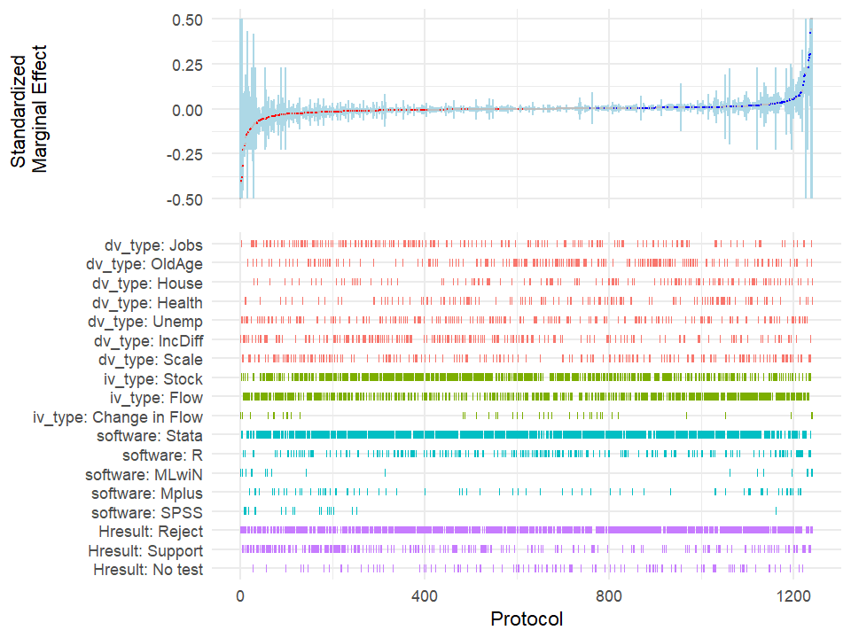

```r
knitr::include_graphics(wdir("Fig1_Overview.png"))
```

```r
NA
NA
NA
```

#### Figure 2. Most Popular Features

#### All DVs

```r
dfx <- crispectest %>%
  mutate(AMEssd = ifelse(iv_type == "Stock", est, NA),
         AMEfsd = ifelse(iv_type == "Flow", est, NA),
         AMEssd = sd(AMEssd, na.rm = T),
         AMEfsd = sd(AMEfsd, na.rm = T),
         estz = est*(AMEssd/AMEfsd),
         lower = lb*(AMEssd/AMEfsd),
         upper = ub*(AMEssd/AMEfsd),
         est = ifelse(iv_type == "Flow", estz, est),
         lb = ifelse(iv_type == "Flow", lower, lb),
         ub = ifelse(iv_type == "Flow", upper, ub),
         # Trim to the range -0.5 to 0.5
         est = ifelse(est < -0.5, -0.5, est),
         est = ifelse(est > 0.5, 0.5, est),
         lb = ifelse(lb < -0.5, -0.5, lb),
         lb = ifelse(lb > 0.5, 0.5, lb),
         ub = ifelse(ub < -0.5, -0.5, ub),
         ub = ifelse(ub > 0.5, 0.5, ub),
         waves = ifelse(w1990!= "0" & w1996!="0" & w2006!="0" & w2016!="0", "All", ifelse(w1990== "0" & w1996=="w1996" & w2006=="w2006" & w2016=="0", "1996/2006", ifelse(w1990== "0" & w1996=="0" & w2006=="w2006" & w2016=="w2016", "2006/2016", "Other"))),
         cases = ifelse(eeurope == 1, "E_Europe", ifelse(allavailable == 1, "All Available", "Rich Dems")))

dfx <- left_join(dfx, popdf_out, by = "id")
dfx$vote <- ifelse(dfx$total_score > 0.65, "Highest", ifelse(dfx$total_score < 0.650001 & dfx$total_score > 0.55, "High", ifelse(dfx$total_score < 0.550001 & dfx$total_score > 0.38, "Mid", ifelse(dfx$total_score < 0.38001, "Low", NA))))
dfx$estimator <- dfx$mator
dfx <- dfx %>%
  mutate(estimator = ifelse(estimator == "logit", "Logit", ifelse(estimator == "bayes", "Bayes", ifelse(estimator == "ols", "OLS", ifelse(estimator == "ologit", "Ord_Logit", ifelse(estimator == "mlogit", "Multi_Logit", ifelse(estimator == "ml_glm", "MLM_GLM", NA)))))))
df3 <- as.data.frame(select(dfx, vote, waves, cases, estimator, est, lb, ub))
  # remove/adjust attributes
  choic <- 1:4
  attr(df3, "choices") <- choic
  rownames(df3) <- NULL
plot_rdf_spec_curve(df3, "est", "lb", "ub", est_color = "grey", est_color_signeg = "red",  choice_ind_point = F, lower_to_upper = 1.75, est_label = "Marginal Effect", ribbon = F)
```

```r
png(filename = wdir("Fig2_Popular.png"), width = 960, height = 720, res = 144)
print(plot_rdf_spec_curve(df3, "est", "lb", "ub", est_color = "grey", est_color_signeg = "red",  choice_ind_point = F, lower_to_upper = 1.75, est_label = "Standardized \nMarginal Effect", ribbon = F))
```

```r
dev.off()
```

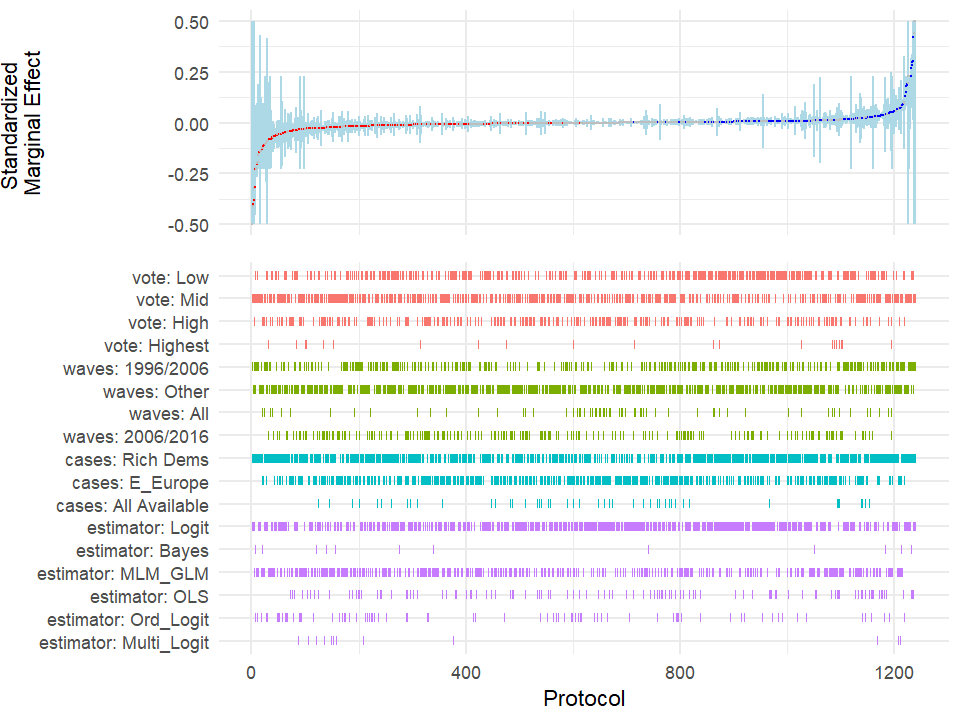

```r
knitr::include_graphics(wdir("Fig2_Popular.png"))
```

```r
NA
```

### Explaining Results Variance With DV Type

```
There were 50 or more warnings (use warnings() to see the first 50)
```

```r
#DVs only
m1a <- lm(AME ~ Jobs + Unemp + IncDiff + OldAge + House + Health + Scale, data = cri)
m1b <- lm(p ~ Jobs + Unemp + IncDiff + OldAge + House + Health + Scale, data = cri)
m1c <- lm(AME ~ Jobs + Unemp + IncDiff + OldAge + House + Health + Scale + p, data = cri)

m2a <- lm(AME ~ Jobs + Unemp + IncDiff + OldAge + House + Health + Scale + stat + topic + belief, data = cri)
m3a <- lm(AME ~ Jobs + Unemp + IncDiff + OldAge + House + Health + Scale + stat + topic + belief + total_score, data = cri)

tab_model(m1a,m1b,m1c, p.style = "stars", show.ci = F, rm.terms = c("(Intercept)"))
```

#### Variance Explained using Team-Weighting

```r
#DVs only
m1aw <- lm(AME ~ Jobs + Unemp + IncDiff + OldAge + House + Health + Scale, data = cri, weight = inv_weight)
m1bw <- lm(p ~ Jobs + Unemp + IncDiff + OldAge + House + Health + Scale, data = cri, weight = inv_weight)
m1cw <- lm(AME ~ Jobs + Unemp + IncDiff + OldAge + House + Health + Scale + p, data = cri, weight = inv_weight)

m2aw <- lm(AME ~ Jobs + Unemp + IncDiff + OldAge + House + Health + Scale + stat + topic + belief, data = cri, weight = inv_weight)
m3aw <- lm(AME ~ Jobs + Unemp + IncDiff + OldAge + House + Health + Scale + stat + topic + belief + total_score, data = cri, weight = inv_weight)

tab_model(m1aw,m1bw,m1cw, p.style = "stars", show.ci = F, rm.terms = c("(Intercept)"))
```

#### Total score explains nothing of variance

```r
tab_model(m2a, m3a,  p.style = "stars", show.ci = F, rm.terms = c("(Intercept)"))
```

```
There were 50 or more warnings (use warnings() to see the first 50)
```

#### With weights

```r
tab_model(m2aw, m3aw,  p.style = "stars", show.ci = F, rm.terms = c("(Intercept)"))
```

```
There were 28 warnings (use warnings() to see them)
```

### For Appendix

```r
agg_png(file = wdir("Fig3_Coeff.png"), width = 800, height = 500, res = 144)
plot_model(m2a, axis.labels = c("Belief: Hyp is True", "Topical Knowledge","Statistical Skills","Multi-Question Scale","Health Care","Housing","Old Age","Income Diff","Unemp","Jobs")) +
  labs(title = "Figure X. Marginal Effects of Immigration on Policy Preferences", subtitle = "By Question Types and Researcher Qualities") +
  geom_hline(yintercept=0) +
  ylim(-0.3,0.3) +

  theme(
  panel.background = element_blank(),
  panel.grid.major = element_line(size = 0.5, linetype = 'solid',
                                colour = "grey80"),
  panel.grid.minor = element_blank(),
  plot.margin = margin(t = 0.5, r = 0.5, b = 0.5, l = 1, unit = "cm"),
  plot.title = element_text(hjust = -6.8),
  plot.subtitle = element_text(hjust = -0.64))
dev.off()
```

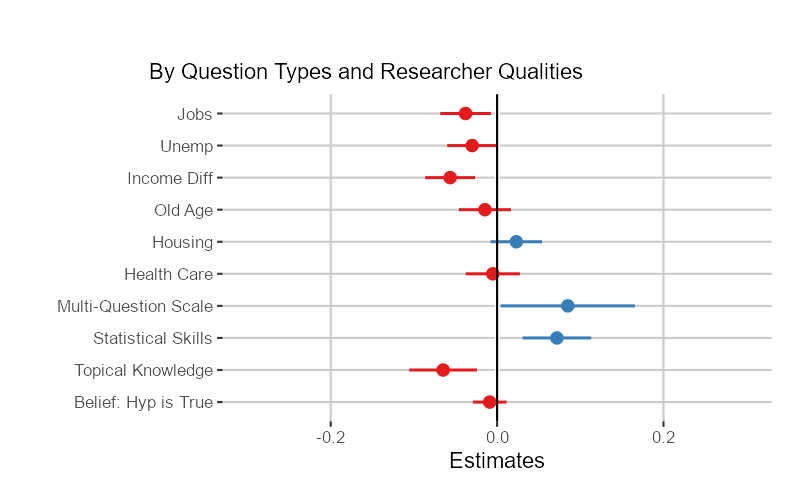

```r
knitr::include_graphics(wdir("Fig3_Coeff.png"))
```

#### Figure 3. Subjective Results

```r
png(filename = wdir("Fig3_Subj.png"), width = 720, height = 620, res = 144)
```

```
There were 50 or more warnings (use warnings() to see the first 50)
```

```r
print(plot_rdf_spec_curve(df4, "est", "lb", "ub", est_color = "grey", est_color_signeg = "red", ribbon_color = hidecolor, choice_ind_point = F, lower_to_upper = 2.5, pt_size = 0.5, est_label = " \nSubjective\nConclusion", ribbon = F))
```

```r
dev.off()
```

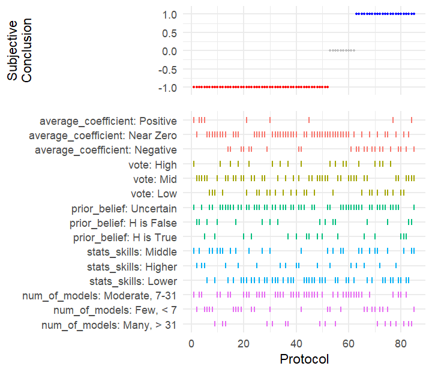

```r
knitr::include_graphics(wdir("Fig3_Subj.png"))
```

```r
ggplot(aes(x = stat, y = AME_Z, color = Hresult), data = cri) +
```

```
There were 50 or more warnings (use warnings() to see the first 50)
```

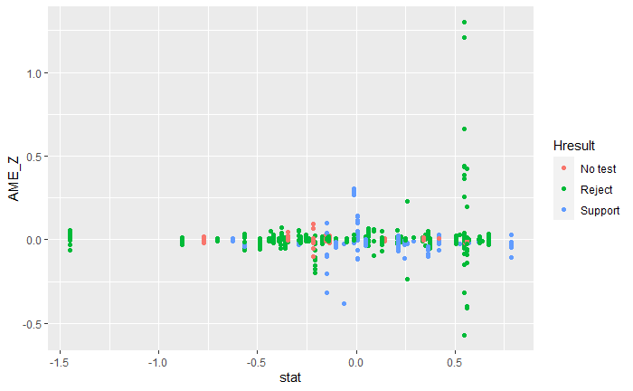

```r
  geom_point()
```

```r
#DVs only
m3 <- lm(Hsup ~ AME + Jobs + Unemp + IncDiff + OldAge + House + Health + Scale, data = cri)
m4 <- lm(Hrej ~ AME + Jobs + Unemp + IncDiff + OldAge + House + Health + Scale, data = cri)
# m5 <- mlogit(HresultF ~ AME + Jobs + Unemp + IncDiff + OldAge + House + Health + Scale + p, data = cri)

m3a <- lm(Hsup ~ AME + Jobs + Unemp + IncDiff + OldAge + House + Health + Scale + stat + topic + belief + total_score + fract_ivC, data = cri)
m4a <- lm(Hrej ~ AME + Jobs + Unemp + IncDiff + OldAge + House + Health + Scale + stat + topic + belief + total_score + fract_ivC, data = cri)

tab_model(m3,m3a,m4,m4a, p.style = "stars", show.ci = F, rm.terms = c("(Intercept)"))
```

### Percent Significant and Choices per Team

Create a variable for the percentage of models supporting the conclusion by team

```r
cri <- cri %>%
  ungroup

# remove AME & p = NA rows so they don't bias the weighting values
cri$ct <- 1

crimis <- subset(cri, !is.na(cri$AME))
crimis <- subset(cri, !is.na(cri$p))

# set up an indicator for deserving / undeserving DVs

crimis <- crimis %>%
  mutate(des = ifelse(Jobs == "Jobs", 0, ifelse(IncDiff == "IncDiff", 0, ifelse(House == "House", 0, ifelse(OldAge == "OldAge", 1, ifelse(Unemp == "Unemp", 1, ifelse(Health == "Health", 1, 0)))))),
         undes = ifelse(OldAge == "OldAge", 0, ifelse(Unemp == "Unemp", 0, ifelse(Health == "Health", 0, ifelse(Jobs == "Jobs", 1, ifelse(IncDiff == "IncDiff", 1, 0))))))

criT <- crimis %>%
  group_by(u_teamid) %>%
  mutate(pct_sig = mean(AME_sup, na.rm =T),
         stock_weight = sum(main_IV_type=="Stock" & main_IV_measurement == "Immigrant, foreign-born", na.rm=T),
         flow_weight = sum(main_IV_type=="Flow" & main_IV_measurement == "Immigrant, foreign-born", na.rm=T),
         cflow_weight = sum(main_IV_type=="Change in Flow" & main_IV_measurement == "Immigrant, foreign-born"),
         outstock_weight = sum(main_IV_type=="Stock" & main_IV_measurement == "Refugee" | main_IV_type=="Stock" & main_IV_measurement == "Non-Western Immigrant" | main_IV_type=="Stock" & main_IV_measurement == "Asylum applicants" | main_IV_type=="Stock" & main_IV_measurement == "Muslim-country Immigrant"),
         outflow_weight = sum(main_IV_type=="Flow" & main_IV_measurement == "Refugee" | main_IV_type=="Flow" & main_IV_measurement == "Non-Western Immigrant" | main_IV_type=="Flow" & main_IV_measurement == "Asylum applicants" | main_IV_type=="Flow" & main_IV_measurement == "Muslim-country Immigrant"),
         instock_weight = sum(main_IV_type == "Stock" & main_IV_measurement == "Western Immigrant"),
         inflow_weight = sum(main_IV_type == "Flow" & main_IV_measurement == "Western Immigrant"),
         sdv_weight = sum(ct[Scale == 0]),
         lat_weight = sum(ct[Scale == "Scale"]),
         des_weight = sum(ct[des == 1]),
         undes_weight = sum(ct[undes == 1])) %>%
  ungroup()

# Remove teams without results

criT <- completeFun(criT, "AME")
criT <- completeFun(criT, "p")
# Sig rate per team + conclusion is later (see chink further down)

cri_team <- aggregate(select(criT, u_teamid, Hresult, AME, AME_Z, AME_sup, AME_sup_p10, upper, lower, p, pct_sig, stat, topic, belief, total_score, inv_weight, DV, Jobs, Unemp, IncDiff, OldAge, Health, House, Scale, num_countries, Hsupport_stock, Hreject_stock, Hnotest_stock, Hsupport_net, Hreject_net, Hnotest_net, Hsup), by = list(criT$u_teamid, criT$Hresult), FUN = mean)

cri_team <- subset(cri_team, u_teamid !=0)


hist(cri_team$pct_sig, main = "", xlab = "Percent of Models with Negative Effects, p<0.05", ylab = "Number of Teams")
```

```r
# Data are not normally distributed, calculate bootstrapped mean and CI

# function to obtain the mean
Bmean <- function(cri_team, pct_sig) {
  d <- cri_team[pct_sig] # allows boot to select sample
    return(mean(d))
}

# function to obtain the sd
Bsd <- function(cri_team, pct_sig) {
  d <- cri_team[pct_sig] # allows boot to select sample
    return(sd(d))
}

# bootstrapping with 1000 replications
results <- boot(data=cri_team$pct_sig, statistic=Bmean, R=1000)
results_sd <- boot(data=cri_team$pct_sig, statistic=Bsd, R=1000)
# view results

plot(results)

# get 95% confidence interval
boot.ci(results, type=c("norm", "basic", "perc", "bca"))
```

```r
plot(results_sd)

# get 95% confidence interval
boot.ci(results_sd, type=c("norm", "basic", "perc", "bca"))
```

```r
# Majority of the models should support the hypothesis to claim support
cri_team$pct_sig_maj <- ifelse(cri_team$AME_sup > 0.5,"aAbove 50pct", ifelse(cri_team$AME_sup > 0.399 & cri_team$AME_sup < 0.50001, "bBtw 40 and 50pct", "cBelow 40pct"))
cri_team$pct_sig_maj_p10 <- ifelse(cri_team$AME_sup_p10 > 0.5,"aAbove 50pct", ifelse(cri_team$AME_sup_p10 > 0.399 & cri_team$AME_sup_p10 < 0.50001, "bBtw 40 and 50pct", "cBelow 40pct"))


ctab_p05 <- ftable(cri_team$pct_sig_maj, cri_team$Hsup)
ctab_p10 <- ftable(cri_team$pct_sig_maj_p10, cri_team$Hsup)

ctab_p05_3h <- ftable(cri_team$pct_sig_maj, cri_team$Group.2)
ctab_p10_3h <- ftable(cri_team$pct_sig_maj_p10, cri_team$Group.2)

cri_team <- select(cri_team, AME_sup, AME_sup_p10, pct_sig, Hsup, everything())

# Explaining the teams who had no majority significant models supporting the Hypothesis but still concluded support.

# Team 6 considers 3 out of 8 effects being positive and significant.
# Team 101 & 62, their support comes from the significant effects of Alesina-fractionalization and MCP
# Team 104, results significant at the p<.1 level

# Explaining the teams with 0.5 percent significant by concluding reject
# 38 found one out of two coefficients significant and negative, but decided the effect was too small and that the percentage of foreign-born (stock) was the better measure as opposed to net migration, and for stock the effect was insig.
# 22 and 69 found 0.5, just not convinced, mixed results.

ctab_p05_3h <- as.data.frame(stats:::format.ftable(ctab_p05_3h))
ctab_p10_3h <- as.data.frame(stats:::format.ftable(ctab_p10_3h))
t1_ctab <- rbind(ctab_p05_3h,ctab_p10_3h)
t1_ctab <- t1_ctab[-c(1,2,6,7),-c(2)]
colnames(t1_ctab) <- c("label","No Test","Reject","Support")
kable(t1_ctab)
```

```r
# Choices and outcomes

# need a weight variable that is the inverse
criT$stock_weight <- 1/criT$stock_weight
criT$flow_weight <- 1/criT$flow_weight
criT$cflow_weight <- 1/criT$cflow_weight
criT$outstock_weight <- 1/criT$outstock_weight
criT$outflow_weight <- 1/criT$outflow_weight
criT$instock_weight <- 1/criT$instock_weight
criT$inflow_weight <- 1/criT$inflow_weight
criT$sdv_weight <- 1/criT$sdv_weight
criT$lat_weight <- 1/criT$lat_weight
criT$des_weight <- 1/criT$des_weight
criT$undes_weight <- 1/criT$undes_weight




###########
#  STOCK  #
###########

# note that 'AME' here just means the number of significant negative tests

stockAME <- weighted.mean(criT$AME_sup[criT$main_IV_type == "Stock" & criT$main_IV_measurement == "Immigrant, foreign-born"], criT$stock_weight[criT$main_IV_type == "Stock" & criT$main_IV_measurement == "Immigrant, foreign-born"], na.rm = T)

stockP <- weighted.mean(criT$p[criT$main_IV_type == "Stock" & criT$main_IV_measurement == "Immigrant, foreign-born"], criT$stock_weight[criT$main_IV_type == "Stock" & criT$main_IV_measurement == "Immigrant, foreign-born"], na.rm = T)

stockSCORE <- weighted.mean(criT$total_score[criT$main_IV_type == "Stock" & criT$main_IV_measurement == "Immigrant, foreign-born"], criT$stock_weight[criT$main_IV_type == "Stock" & criT$main_IV_measurement == "Immigrant, foreign-born"], na.rm=T)

# count number of teams that have a stock model as at least one of their models

stockN <- sum(criT$ct[criT$main_IV_type == "Stock" & criT$main_IV_measurement == "Immigrant, foreign-born" & criT$stock_weight!="Inf"] * criT$stock_weight[criT$main_IV_type == "Stock" & criT$main_IV_measurement == "Immigrant, foreign-born" & criT$stock_weight!="Inf"], na.rm=T)

stockNtotal <- sum(criT$ct[criT$main_IV_type == "Stock" & criT$main_IV_measurement == "Immigrant, foreign-born"])/sum(criT$ct[criT$main_IV_measurement == "Immigrant, foreign-born" & criT$main_IV_type != "Change in Flow"])

stockNtotalmods <- sum(criT$ct[criT$main_IV_type != "Change in Flow" & criT$main_IV_measurement == "Immigrant, foreign-born"])

###########
#  FLOW   #
###########

flowAME <- weighted.mean(criT$AME_sup[criT$main_IV_type == "Flow" & criT$main_IV_measurement == "Immigrant, foreign-born"], criT$flow_weight[criT$main_IV_type == "Flow" & criT$main_IV_measurement == "Immigrant, foreign-born"], na.rm = T)

flowP <- weighted.mean(criT$p[criT$main_IV_type == "Flow" & criT$main_IV_measurement == "Immigrant, foreign-born"], criT$flow_weight[criT$main_IV_type == "Flow" & criT$main_IV_measurement == "Immigrant, foreign-born"], na.rm = T)

flowSCORE <- weighted.mean(criT$total_score[criT$main_IV_type == "Flow" & criT$main_IV_measurement == "Immigrant, foreign-born"], criT$flow_weight[criT$main_IV_type == "Flow" & criT$main_IV_measurement == "Immigrant, foreign-born"], na.rm=T)

# count number of teams that have a flow model as at least one of their models

flowN <- sum(criT$ct[criT$main_IV_type == "Flow" & criT$main_IV_measurement == "Immigrant, foreign-born" & criT$flow_weight!="Inf"] * criT$flow_weight[criT$main_IV_type == "Flow" & criT$main_IV_measurement == "Immigrant, foreign-born" & criT$flow_weight!="Inf"], na.rm=T)

flowNtotal <- sum(criT$ct[criT$main_IV_type == "Flow" & criT$main_IV_measurement == "Immigrant, foreign-born"])/sum(criT$ct[criT$main_IV_measurement == "Immigrant, foreign-born" & criT$main_IV_type != "Change in Flow"])

flowNtotalmods <- sum(criT$ct[criT$main_IV_type != "Change in Flow" & criT$main_IV_measurement == "Immigrant, foreign-born"])

#####################
#  CHANGE IN FLOW   #
#####################

cflowAME <- weighted.mean(criT$AME_sup[criT$main_IV_type == "Change in Flow" & criT$main_IV_measurement == "Immigrant, foreign-born"], criT$cflow_weight[criT$main_IV_type == "Change in Flow" & criT$main_IV_measurement == "Immigrant, foreign-born"], na.rm = T)

cflowP <- weighted.mean(criT$p[criT$main_IV_type == "Change in Flow" & criT$main_IV_measurement == "Immigrant, foreign-born"], criT$cflow_weight[criT$main_IV_type == "Change in Flow" & criT$main_IV_measurement == "Immigrant, foreign-born"], na.rm = T)

cflowSCORE <- weighted.mean(criT$total_score[criT$main_IV_type == "Change in Flow" & criT$main_IV_measurement == "Immigrant, foreign-born"], criT$cflow_weight[criT$main_IV_type == "Change in Flow" & criT$main_IV_measurement == "Immigrant, foreign-born"], na.rm=T)

# count number of teams that have a cflow model as at least one of their models

cflowN <- sum(criT$ct[criT$main_IV_type == "Change in Flow" & criT$main_IV_measurement == "Immigrant, foreign-born" & criT$cflow_weight!="Inf"] * criT$cflow_weight[criT$main_IV_type == "Change in Flow" & criT$main_IV_measurement == "Immigrant, foreign-born" & criT$cflow_weight!="Inf"], na.rm=T)

cflowNtotal <- sum(criT$ct[criT$main_IV_type == "Change in Flow" & criT$main_IV_measurement == "Immigrant, foreign-born"])/sum(criT$ct[criT$main_IV_measurement == "Immigrant, foreign-born"])

cflowNtotalmods <- sum(criT$ct[criT$main_IV_measurement == "Immigrant, foreign-born"])

# Outgroup = refugee, non-western and Muslim-country immigrants

#####################
#  OUTGROUP STOCK   #
#####################

outstockAME <- weighted.mean(criT$AME_sup[criT$main_IV_type == "Stock" & criT$main_IV_measurement == "Refugee" | criT$main_IV_type=="Stock" & criT$main_IV_measurement == "Non-Western Immigrant" | criT$main_IV_type=="Stock" & criT$main_IV_measurement == "Asylum applicants" | criT$main_IV_type=="Stock" & criT$main_IV_measurement == "Muslim-country Immigrant"], criT$outstock_weight[criT$main_IV_type == "Stock" & criT$main_IV_measurement == "Refugee" | criT$main_IV_type=="Stock" & criT$main_IV_measurement == "Non-Western Immigrant" | criT$main_IV_type=="Stock" & criT$main_IV_measurement == "Asylum applicants" | criT$main_IV_type=="Stock" & criT$main_IV_measurement == "Muslim-country Immigrant"], na.rm = T)

outstockP <- weighted.mean(criT$p[criT$main_IV_type == "Stock" & criT$main_IV_measurement == "Refugee" | criT$main_IV_type=="Stock" & criT$main_IV_measurement == "Non-Western Immigrant" | criT$main_IV_type=="Stock" & criT$main_IV_measurement == "Asylum applicants" | criT$main_IV_type=="Stock" & criT$main_IV_measurement == "Muslim-country Immigrant"], criT$outstock_weight[criT$main_IV_type == "Stock" & criT$main_IV_measurement == "Refugee" | criT$main_IV_type=="Stock" & criT$main_IV_measurement == "Non-Western Immigrant" | criT$main_IV_type=="Stock" & criT$main_IV_measurement == "Asylum applicants" | criT$main_IV_type=="Stock" & criT$main_IV_measurement == "Muslim-country Immigrant"], na.rm = T)
```

```r
outstockSCORE <- weighted.mean(criT$total_score[criT$main_IV_type == "Stock" & criT$main_IV_measurement == "Refugee" | criT$main_IV_type=="Stock" & criT$main_IV_measurement == "Non-Western Immigrant" | criT$main_IV_type=="Stock" & criT$main_IV_measurement == "Asylum applicants" | criT$main_IV_type=="Stock" & criT$main_IV_measurement == "Muslim-country Immigrant"], criT$outstock_weight[criT$main_IV_type == "Stock"& criT$main_IV_measurement == "Refugee" | criT$main_IV_type=="Stock" & criT$main_IV_measurement == "Non-Western Immigrant" | criT$main_IV_type=="Stock" & criT$main_IV_measurement == "Asylum applicants" | criT$main_IV_type=="Stock" & criT$main_IV_measurement == "Muslim-country Immigrant"], na.rm=T)

# count number of teams that have a outstock model as at least one of their models

outstockN <- sum(criT$ct[criT$main_IV_type == "Stock" & criT$main_IV_measurement == "Refugee" & criT$outstock_weight!="Inf" | criT$main_IV_type=="Stock" & criT$main_IV_measurement == "Non-Western Immigrant" & criT$outstock_weight!="Inf" | criT$main_IV_type=="Stock" & criT$main_IV_measurement == "Asylum applicants" & criT$outstock_weight!="Inf" | criT$main_IV_type=="Stock" & criT$main_IV_measurement == "Muslim-country Immigrant" & criT$outstock_weight!="Inf"] * criT$outstock_weight[criT$main_IV_type == "Stock" & criT$main_IV_measurement == "Refugee" & criT$outstock_weight!="Inf" | criT$main_IV_type=="Stock" & criT$main_IV_measurement == "Non-Western Immigrant" & criT$outstock_weight!="Inf" | criT$main_IV_type=="Stock" & criT$main_IV_measurement == "Asylum applicants" & criT$outstock_weight!="Inf" | criT$main_IV_type=="Stock" & criT$main_IV_measurement == "Muslim-country Immigrant" & criT$outstock_weight!="Inf"], na.rm=T)

# use stock of foreign-born as reference
outstockNtotal <- sum(criT$ct[criT$main_IV_type == "Stock" & criT$main_IV_measurement != "Immigrant, foreign-born"])/(sum(criT$ct[criT$main_IV_type == "Stock" & criT$main_IV_measurement != "Immigrant, foreign-born"])+ stockNtotalmods)

outstockNtotalmods <- sum(criT$ct[criT$main_IV_type == "Stock" & criT$main_IV_measurement != "Immigrant, foreign-born"]) + stockNtotalmods



#####################
#  OUTGROUP FLOW    #
#####################



outflowAME <- weighted.mean(criT$AME_sup[criT$main_IV_type == "Flow" & criT$main_IV_measurement == "Refugee" | criT$main_IV_type=="Flow" & criT$main_IV_measurement == "Non-Western Immigrant" | criT$main_IV_type=="Flow" & criT$main_IV_measurement == "Asylum applicants" | criT$main_IV_type=="Flow" & criT$main_IV_measurement == "Muslim-country Immigrant"], criT$outflow_weight[criT$main_IV_type == "Flow" & criT$main_IV_measurement == "Refugee" | criT$main_IV_type=="Flow" & criT$main_IV_measurement == "Non-Western Immigrant" | criT$main_IV_type=="Flow" & criT$main_IV_measurement == "Asylum applicants" | criT$main_IV_type=="Flow" & criT$main_IV_measurement == "Muslim-country Immigrant"], na.rm = T)

outflowP <- weighted.mean(criT$p[criT$main_IV_type == "Flow" & criT$main_IV_measurement == "Refugee" | criT$main_IV_type=="Flow" & criT$main_IV_measurement == "Non-Western Immigrant" | criT$main_IV_type=="Flow" & criT$main_IV_measurement == "Asylum applicants" | criT$main_IV_type=="Flow" & criT$main_IV_measurement == "Muslim-country Immigrant"], criT$outflow_weight[criT$main_IV_type == "Flow" & criT$main_IV_measurement == "Refugee" | criT$main_IV_type=="Flow" & criT$main_IV_measurement == "Non-Western Immigrant" | criT$main_IV_type=="Flow" & criT$main_IV_measurement == "Asylum applicants" | criT$main_IV_type=="Flow" & criT$main_IV_measurement == "Muslim-country Immigrant"], na.rm = T)

outflowSCORE <- weighted.mean(criT$total_score[criT$main_IV_type == "Flow" & criT$main_IV_measurement == "Refugee" | criT$main_IV_type=="Flow" & criT$main_IV_measurement == "Non-Western Immigrant" | criT$main_IV_type=="Flow" & criT$main_IV_measurement == "Asylum applicants" | criT$main_IV_type=="Flow" & criT$main_IV_measurement == "Muslim-country Immigrant"], criT$outflow_weight[criT$main_IV_type == "Flow"& criT$main_IV_measurement == "Refugee" | criT$main_IV_type=="Flow" & criT$main_IV_measurement == "Non-Western Immigrant" | criT$main_IV_type=="Flow" & criT$main_IV_measurement == "Asylum applicants" | criT$main_IV_type=="Flow" & criT$main_IV_measurement == "Muslim-country Immigrant"], na.rm=T)

# count number of teams that have a outflow model as at least one of their models

outflowN <- sum(criT$ct[criT$main_IV_type == "Flow" & criT$main_IV_measurement == "Refugee" & criT$outflow_weight!="Inf" | criT$main_IV_type=="Flow" & criT$main_IV_measurement == "Non-Western Immigrant" & criT$outflow_weight!="Inf" | criT$main_IV_type=="Flow" & criT$main_IV_measurement == "Asylum applicants" & criT$outflow_weight!="Inf" | criT$main_IV_type=="Flow" & criT$main_IV_measurement == "Muslim-country Immigrant" & criT$outflow_weight!="Inf"] * criT$outflow_weight[criT$main_IV_type == "Flow" & criT$main_IV_measurement == "Refugee" & criT$outflow_weight!="Inf" | criT$main_IV_type=="Flow" & criT$main_IV_measurement == "Non-Western Immigrant" & criT$outflow_weight!="Inf" | criT$main_IV_type=="Flow" & criT$main_IV_measurement == "Asylum applicants" & criT$outflow_weight!="Inf" | criT$main_IV_type=="Flow" & criT$main_IV_measurement == "Muslim-country Immigrant" & criT$outflow_weight!="Inf"], na.rm=T)

# use flow of foreign-born as reference
outflowNtotal <- sum(criT$ct[criT$main_IV_type == "Flow" & criT$main_IV_measurement != "Immigrant, foreign-born"])/(sum(criT$ct[criT$main_IV_type == "Flow" & criT$main_IV_measurement != "Immigrant, foreign-born"]) + flowNtotalmods)

outflowNtotalmods <- sum(criT$ct[criT$main_IV_type == "Flow" & criT$main_IV_measurement != "Immigrant, foreign-born"]) + flowNtotalmods


####################
#  Single Item DV  #
####################

# note that 'AME' here just means the number of significant negative tests

sdvAME <- weighted.mean(criT$AME_sup[criT$Scale == 0], criT$sdv_weight[criT$Scale == 0], na.rm = T)

sdvP <- weighted.mean(criT$p[criT$Scale == 0], criT$sdv_weight[criT$Scale == 0], na.rm = T)
```

```r
sdvSCORE <- weighted.mean(criT$total_score[criT$Scale == 0], criT$sdv_weight[criT$Scale == 0], na.rm=T)

# count number of teams that have a sdv model as at least one of their models

sdvN <- sum(criT$ct[criT$Scale == 0 & criT$sdv_weight!="Inf"] * criT$sdv_weight[criT$Scale == 0 & criT$sdv_weight!="Inf"], na.rm=T)

sdvNtotal <- sum(criT$ct[criT$Scale == 0])/sum(criT$ct)

sdvNtotalmods <- sum(criT$ct[criT$Scale == 0])

####################
#  Latent Scale DV #
####################

# note that 'AME' here just means the number of significant negative tests

latAME <- weighted.mean(criT$AME_sup[criT$Scale == "Scale"], criT$lat_weight[criT$Scale == "Scale"], na.rm = T)

latP <- weighted.mean(criT$p[criT$Scale == "Scale"], criT$lat_weight[criT$Scale == "Scale"], na.rm = T)

latSCORE <- weighted.mean(criT$total_score[criT$Scale == "Scale"], criT$lat_weight[criT$Scale == "Scale"], na.rm=T)

# count number of teams that have a lat model as at least one of their models

latN <- sum(criT$ct[criT$Scale == "Scale" & criT$lat_weight!="Inf"] * criT$lat_weight[criT$Scale == "Scale" & criT$lat_weight!="Inf"], na.rm=T)

latNtotal <- sum(criT$ct[criT$Scale == "Scale"])/sum(criT$ct)

latNtotalmods <- sum(criT$ct[criT$Scale == "Scale"])

#######################
#  Deserving policies #
#######################

# OldAge, Health & Unemp

# note that 'AME' here just means the number of significant negative tests

desAME <- weighted.mean(criT$AME_sup[(criT$des == 1)], criT$des_weight[(criT$des == 1)], na.rm = T)

desP <- weighted.mean(criT$p[(criT$des == 1)], criT$des_weight[(criT$des == 1)], na.rm = T)

desSCORE <- weighted.mean(criT$total_score[(criT$des == 1)], criT$des_weight[(criT$des == 1)], na.rm=T)

# count number of teams that have a des model as at least one of their models

desN <- sum(criT$ct[criT$des == 1 & criT$des_weight!="Inf"] * criT$des_weight[criT$des == 1 & criT$des_weight!="Inf"], na.rm=T)

desNtotal <- sum(criT$ct[criT$des == 1])/sum(criT$ct)

desNtotalmods <- sum(criT$ct[criT$des == 1])

#######################
#  Un-Deserving policies #
#######################

# OldAge, Health & Unemp

# note that 'AME' here just means the number of significant negative tests

undesAME <- weighted.mean(criT$AME_sup[(criT$undes == 1)], criT$undes_weight[(criT$undes == 1)], na.rm = T)

undesP <- weighted.mean(criT$p[(criT$undes == 1)], criT$undes_weight[(criT$undes == 1)], na.rm = T)

undesSCORE <- weighted.mean(criT$total_score[(criT$undes == 1)], criT$undes_weight[(criT$undes == 1)], na.rm=T)

# count number of teams that have a undes model as at least one of their models

undesN <- sum(criT$ct[criT$undes == 1 & criT$undes_weight!="Inf"] * criT$undes_weight[criT$undes == 1 & criT$undes_weight!="Inf"], na.rm=T)

undesNtotal <- sum(criT$ct[criT$undes == 1])/sum(criT$ct)

undesNtotalmods <- sum(criT$ct[criT$undes == 1])
```

For now, ingroup stock and flow are not used in the table.

## Table 2. Research Decisions and their Subjective and Objective Outcomes

```r
# Now compile Table 1

t1 <- data.frame(matrix(nrow=5,ncol=13))
colnames(t1) <- c("Yes","No","Avgscore","Gap1","Gap2","Gap3",   "Pct_Support","Gapa","Gapb","Gapc","Incl","Total","Pct_With")

t1[1,1:13] <- c(stockN,77-stockN,round(stockSCORE,2),NA,NA,NA,round(100*stockAME,1),NA,NA,NA,stockP,stockNtotalmods,round(100*stockNtotal,1))

t1[2,1:13] <- c(flowN,77-flowN,round(flowSCORE,2),NA,NA,NA,round(100*flowAME,1),NA,NA,NA,flowP,flowNtotalmods,round(100*flowNtotal,1))

t1[3,1:13] <- c(cflowN,77-cflowN,round(cflowSCORE,2),NA,NA,NA,round(100*cflowAME,1),NA,NA,NA,cflowP,cflowNtotalmods,round(100*cflowNtotal,1))

t1[4,1:13] <- c(outstockN,77-outstockN,round(outstockSCORE,2),NA,NA,NA,round(100*outstockAME,1),NA,NA,NA,outstockP,outstockNtotalmods,round(100*outstockNtotal,1))

t1[5,1:13] <- c(outflowN,77-outflowN,round(outflowSCORE,2),NA,NA,NA,round(100*outflowAME,1),NA,NA,NA,outflowP,outflowNtotalmods,round(100*outflowNtotal,1))

t1[6,1:13] <- c(sdvN,77-sdvN,round(sdvSCORE,2),NA,NA,NA,round(100*sdvAME,1),NA,NA,NA,sdvP,sdvNtotalmods,round(100*sdvNtotal,1))

t1[7,1:13] <- c(latN,77-latN,round(latSCORE,2),NA,NA,NA,round(100*latAME,1),NA,NA,NA,latP,latNtotalmods,round(100*latNtotal,1))

t1[8,1:13] <- c(desN,77-desN,round(desSCORE,2),NA,NA,NA,round(100*desAME,1),NA,NA,NA,desP,desNtotalmods,round(100*desNtotal,1))

t1[9,1:13] <- c(undesN,77-undesN,round(undesSCORE,2),NA,NA,NA,round(100*undesAME,1),NA,NA,NA,undesP,undesNtotalmods,round(100*undesNtotal,1))

# unique(criT$u_teamid)
```

##### % Sig. Pooled Analysis

This should be run with ‘no test’ models removed.

```r
criN <- subset(criT, Hresult != "No test")


mX1 <- lm(Hsup ~ AME, data = criN)
mX2 <- lm(Hsup ~ AME + pct_sig, data = criN)
mX3 <- lm(Hsup ~ AME + pct_sig + Scale + total_score, data = criN)
mX4 <- lm(Hsup ~ AME + pct_sig + Scale + stat + topic + belief + total_score, data = criN)

tab_model(mX1,mX2,mX3,mX4, p.style = "stars", show.ci = F, rm.terms = c("(Intercept)"))
```

##### % Sig. Team-Level

with ‘no test’ models removed (just support versus reject)

```r
criP <- select(criN, u_teamid, Hresult, Hsup, AME, AME_Z, upper, lower, p, pct_sig, stat, topic, belief, total_score, inv_weight, DV, Jobs, Unemp, IncDiff, OldAge, Health, House, Scale, num_countries)
criT <- aggregate(criP, by = list(criP$u_teamid, criP$Hresult), FUN = mean)

mX1t <- lm(Hsup ~ AME_Z, data = criT)
mX2t <- lm(Hsup ~ AME_Z + pct_sig, data = criT)
mX3t <- lm(Hsup ~ AME_Z + pct_sig + total_score, data = criT)
mX4t <- lm(Hsup ~ AME_Z + pct_sig + stat + topic + belief + total_score, data = criT)

tab_model(mX1t,mX2t,mX3t,mX4t, p.style = "stars", show.ci = F, rm.terms = c("(Intercept)"))
```

### A Particular DV Significance Predicting Result

For this we take only teams that modeled single-items. We make a variable representing whether a significant negative effect was found for each DV as a dichotmous variable. Then regress these on the likelihood of Hsupport, and vice-versa for Hreject. We have to exclude House and Health, because some teams did not include them because they were ‘primed’ to use only 4 DVs because they were in the experimental replication group, even though our instructions asked the teams to use all 6. We remove the Scale models.

Result is that it does not matter

```r
criPP <- criP %>%
  mutate(JobsS = ifelse(Scale=="Scale",0,ifelse(AME < 0 & p < 0.05 & Jobs=="Jobs",1,0)),
         UnempS = ifelse(Scale=="Scale",0,ifelse(AME < 0 & p < 0.05 & Unemp=="Unemp",1,0)),
         IncDiffS = ifelse(Scale=="Scale",0,ifelse(AME < 0 & p < 0.05 & IncDiff=="IncDiff",1,0)),
         OldAgeS = ifelse(Scale=="Scale",0,ifelse(AME < 0 & p < 0.05 & OldAge=="OldAge",1,0)),
         JobsR = ifelse(Scale=="Scale",0,ifelse(AME > 0 & p < 0.05 & Jobs=="Jobs",1,0)),
         UnempR = ifelse(Scale=="Scale",0,ifelse(AME > 0 & p < 0.05 & Unemp=="Unemp",1,0)),
         IncDiffR = ifelse(Scale=="Scale",0,ifelse(AME > 0 & p < 0.05 & IncDiff=="IncDiff",1,0)),
         OldAgeR = ifelse(Scale=="Scale",0,ifelse(AME > 0 & p < 0.05 & OldAge=="OldAge",1,0)))
criPP <- criPP %>%
  group_by(u_teamid) %>%
  mutate(JobsS = max(JobsS),
         UnempS = max(UnempS),
         IncDiffS = max(IncDiffS),
         OldAgeS = max(OldAgeS),
         JobsR = max(JobsR),
         UnempR = max(UnempR),
         IncDiffR = max(IncDiffR),
         OldAgeR = max(OldAgeR),) %>%
  ungroup()

criPPT<- aggregate(criPP, by = list(criPP$u_teamid, criPP$Hresult), FUN = mean)
criPPT$num_countries <- round(criPPT$num_countries, 0)
mX1ts <- lm(Hsup ~ JobsS + UnempS + IncDiffS + OldAgeS, data = criPPT)
mX1tsa <- lm(Hsup ~ JobsS + UnempS + IncDiffS + OldAgeS + JobsS*IncDiffS, data = criPPT)
mX2ts <- lm(Hsup ~ AME_Z + JobsS + UnempS + IncDiffS + OldAgeS, data = criPPT)
mX3ts <- lm(Hsup ~ AME_Z + pct_sig + JobsS + UnempS + IncDiffS + OldAgeS, data = criPPT)
mX4ts <- lm(Hsup ~ AME_Z + pct_sig + JobsS + UnempS + IncDiffS + OldAgeS + stat + topic + belief + total_score, data = criPPT)

tab_model(mX1ts,mX1tsa,mX2ts,mX3ts,mX4ts, p.style = "stars", show.ci = F, rm.terms = c("(Intercept)"))
```

### Raincloud Plots

```r
plot_model(m2a, axis.labels = c("Belief: Hyp is True", "Topical Knowledge","Statistical Skills","Multi-Question Scale","Health Care","Housing","Old Age","Income Diff","Unemp","Jobs")) +
```

```
There were 50 or more warnings (use warnings() to see the first 50)
```

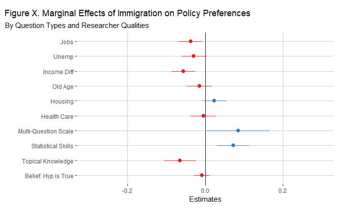

```r
  labs(title = "Figure X. Marginal Effects of Immigration on Policy Preferences", subtitle = "By Question Types and Researcher Qualities") +
  geom_hline(yintercept=0) +
  ylim(-0.3,0.3) +

  theme(
  panel.background = element_blank(),
  panel.grid.major = element_line(size = 0.5, linetype = 'solid',
                                colour = "grey80"),
  panel.grid.minor = element_blank(),
  plot.margin = margin(t = 0.5, r = 0.5, b = 0.5, l = 1, unit = "cm"),
  plot.title = element_text(hjust = -6.8),
  plot.subtitle = element_text(hjust = -0.64))
```

```r
NA
```

```r
tab_model(m2a, m3a,  p.style = "stars", show.ci = F, rm.terms = c("(Intercept)"))
```

```r
# set up raincloud funciton in ggplot, you have to get this file from https://github.com/RainCloudPlots/RainCloudPlots, we should CITE them, see git instructions
```

```
There were 50 or more warnings (use warnings() to see the first 50)
```

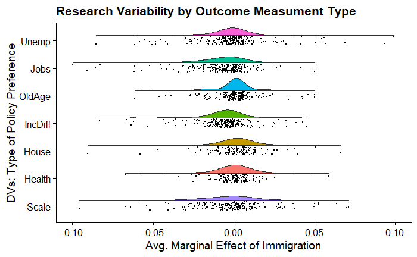

```r
source(paste0(wd,"/R_rainclouds.R"))

pacman::p_load("cowplot","readr")

# get clean grouping variable (all scale types in one factor)
cri <- cri %>%
  mutate(DVs = ifelse(Scale=="Scale","Scale",DV),
         AME_Zt = ifelse(AME_Z > 1, 1, AME_Z),
         AME_Zt = ifelse(AME_Zt < -1, -1, AME_Zt),
         iv_type2 = ifelse(main_IV_type=="Change in Flow","Flow",main_IV_type),
         iv_type2 = as.factor(iv_type2),
         DVn = as.factor(DVs))

cri$DVnn <- (as.numeric(as.factor(cri$DVn))-.15)

rain1 <- ggplot(cri,aes(x=DVs,y=AME_Zt,fill = DVs))+
  geom_flat_violin(position = position_nudge(x = .2, y = 0),adjust =2)+
  geom_point(position = position_jitter(width = .15), size = .25)+
  ylab('Avg. Marginal Effect of Immigration')+xlab('DVs: Type of Policy Preference')+
  coord_flip()+theme_cowplot()+guides(fill = FALSE)+
  ylim(-0.1,0.1)+
  scale_x_discrete(limits = c("Scale","Health", "House","IncDiff","OldAge","Jobs","Unemp")) +
  ggtitle('Research Variability by Outcome Measument Type')
rain1
```

```r
NA
NA
```

```r
png(filename = wdir("Fig4_Rain.png"), height = 720, width = 800, res = 144)
rain2
dev.off()
```

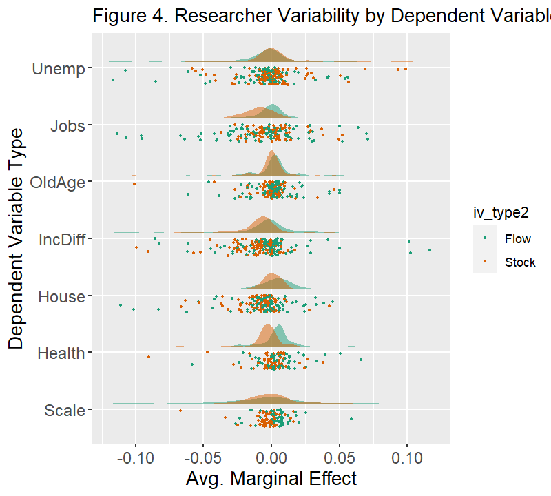

```r
knitr::include_graphics( wdir("Fig4_Rain.png"))
```

#### Quantify the difference in variance by group

##### First a Table of Means and Variances

```r
tab_mv <- as.data.frame(matrix(nrow = 7, ncol = 7))
tab_mv[,1] <- c("Unemp","Jobs","OldAge","IncDiff","House","Health", "Scale")
colnames(tab_mv) <- c("Dep Var","Stock_Mean","Stock_SD","Flow_Mean","Flow_SD","Mean_P","SD_P")

# Get means for stock models
tab_mv[1,2] <- mean(cri$AME_Zt[cri$iv_type2 == "Stock" & cri$DVn == "Unemp"], na.rm = T)
tab_mv[2,2] <- mean(cri$AME_Zt[cri$iv_type2 == "Stock" & cri$DVn == "Jobs"], na.rm = T)
tab_mv[3,2] <- mean(cri$AME_Zt[cri$iv_type2 == "Stock" & cri$DVn == "OldAge"], na.rm = T)
tab_mv[4,2] <- mean(cri$AME_Zt[cri$iv_type2 == "Stock" & cri$DVn == "IncDiff"], na.rm = T)
tab_mv[5,2] <- mean(cri$AME_Zt[cri$iv_type2 == "Stock" & cri$DVn == "House"], na.rm = T)
tab_mv[6,2] <- mean(cri$AME_Zt[cri$iv_type2 == "Stock" & cri$DVn == "Health"], na.rm = T)
tab_mv[7,2] <- mean(cri$AME_Zt[cri$iv_type2 == "Stock" & cri$DVn == "Scale"], na.rm = T)

# Get SD for stock models
tab_mv[1,3] <- sd(cri$AME_Zt[cri$iv_type2 == "Stock" & cri$DVn == "Unemp"], na.rm = T)
tab_mv[2,3] <- sd(cri$AME_Zt[cri$iv_type2 == "Stock" & cri$DVn == "Jobs"], na.rm = T)
tab_mv[3,3] <- sd(cri$AME_Zt[cri$iv_type2 == "Stock" & cri$DVn == "OldAge"], na.rm = T)
tab_mv[4,3] <- sd(cri$AME_Zt[cri$iv_type2 == "Stock" & cri$DVn == "IncDiff"], na.rm = T)
tab_mv[5,3] <- sd(cri$AME_Zt[cri$iv_type2 == "Stock" & cri$DVn == "House"], na.rm = T)
tab_mv[6,3] <- sd(cri$AME_Zt[cri$iv_type2 == "Stock" & cri$DVn == "Health"], na.rm = T)
tab_mv[7,3] <- sd(cri$AME_Zt[cri$iv_type2 == "Stock" & cri$DVn == "Scale"], na.rm = T)

# Get means for flow  models
tab_mv[1,4] <- mean(cri$AME_Zt[cri$iv_type2 == "Flow" & cri$DVn == "Unemp"], na.rm = T)
tab_mv[2,4] <- mean(cri$AME_Zt[cri$iv_type2 == "Flow" & cri$DVn == "Jobs"], na.rm = T)
tab_mv[3,4] <- mean(cri$AME_Zt[cri$iv_type2 == "Flow" & cri$DVn == "OldAge"], na.rm = T)
tab_mv[4,4] <- mean(cri$AME_Zt[cri$iv_type2 == "Flow" & cri$DVn == "IncDiff"], na.rm = T)
tab_mv[5,4] <- mean(cri$AME_Zt[cri$iv_type2 == "Flow" & cri$DVn == "House"], na.rm = T)
tab_mv[6,4] <- mean(cri$AME_Zt[cri$iv_type2 == "Flow" & cri$DVn == "Health"], na.rm = T)
tab_mv[7,4] <- mean(cri$AME_Zt[cri$iv_type2 == "Flow" & cri$DVn == "Scale"], na.rm = T)

# Get SD for stock models
tab_mv[1,5] <- sd(cri$AME_Zt[cri$iv_type2 == "Flow" & cri$DVn == "Unemp"], na.rm = T)
tab_mv[2,5] <- sd(cri$AME_Zt[cri$iv_type2 == "Flow" & cri$DVn == "Jobs"], na.rm = T)
tab_mv[3,5] <- sd(cri$AME_Zt[cri$iv_type2 == "Flow" & cri$DVn == "OldAge"], na.rm = T)
tab_mv[4,5] <- sd(cri$AME_Zt[cri$iv_type2 == "Flow" & cri$DVn == "IncDiff"], na.rm = T)
tab_mv[5,5] <- sd(cri$AME_Zt[cri$iv_type2 == "Flow" & cri$DVn == "House"], na.rm = T)
tab_mv[6,5] <- sd(cri$AME_Zt[cri$iv_type2 == "Flow" & cri$DVn == "Health"], na.rm = T)
tab_mv[7,5] <- sd(cri$AME_Zt[cri$iv_type2 == "Flow" & cri$DVn == "Scale"], na.rm = T)

# mean p-values
tab_mv$Mean_P <- pt((tab_mv$Stock_Mean-tab_mv$Flow_Mean)/sqrt(((599*tab_mv$Stock_SD^2) + (599*tab_mv$Flow_SD^2))/(1198)),1198)

# variance p-values

tab_mv$f <- ifelse(tab_mv$Stock_SD > tab_mv$Flow_SD, (tab_mv$Stock_SD^2)/(tab_mv$Flow_SD^2),(tab_mv$Flow_SD^2)/(tab_mv$Stock_SD^2))

tab_mv$SD_P <- round(pf(tab_mv$f, 77, 77, lower.tail = F),4)

tab_mv <- tab_mv[1:7,1:7]
```

#### Figure 5. Spec Curve. Stock Models Only

```r
png(filename = wdir("Fig5_Stock_Popular.png"), width = 960, height = 720, res = 144)
plot_rdf_spec_curve(df3s, "est", "lb", "ub", est_color = "grey", est_color_signeg = "red",  choice_ind_point = F, lower_to_upper = 1.75, est_label = "Standardized \nMarginal Effect", ribbon = F)
dev.off()
```

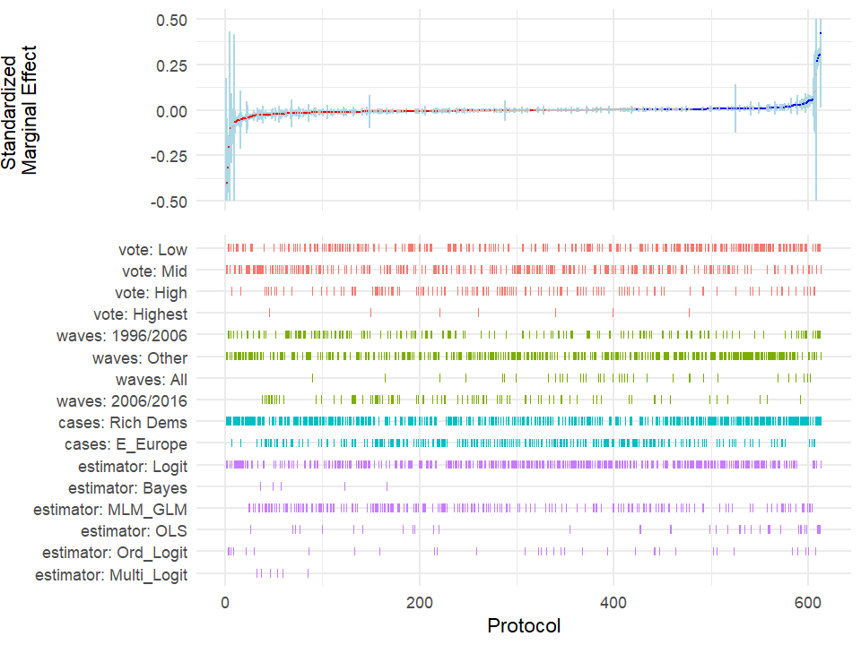

```r
knitr::include_graphics(wdir("Fig5_Stock_Popular.png"))
```

#### Figure 6. Spec Curve. Flow Models Only

```r
df3f <- subset(dfx, dfx$iv_type == "Flow")

df3f <- as.data.frame(select(df3f, vote, waves, cases, estimator, est, lb, ub))

  # remove/adjust attributes
  choic <- 1:4
  attr(df3f, "choices") <- choic
  rownames(df3f) <- NULL

png(filename = wdir("Fig5_Stock_Popular.png"), width = 960, height = 720, res = 144)
plot_rdf_spec_curve(df3f, "est", "lb", "ub", est_color = "grey", est_color_signeg = "red",  choice_ind_point = F, lower_to_upper = 1.75, est_label = "Standardized \nMarginal Effect", ribbon = F)
dev.off()
```

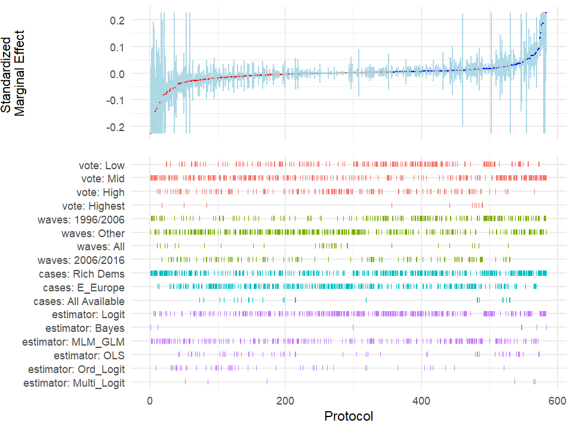

```r
knitr::include_graphics(wdir("Fig5_Stock_Popular.png"))
```

```r
# dichotomize researcher qualities
cri <- cri %>%
  mutate(topic_d = ifelse(topic > 0, 1, 0),
         belief_d = ifelse(belief > 0, 1, 0),
         stat_d = ifelse(stat > 0, 1, 0),
         belief_strength_d = ifelse(belief_strength > 4, 1, 0),
         topic_interest_d = ifelse(topic_interest > 4.4, 1, 0),
         pub_interest_d = ifelse(pub_interest > 4.4, 1, 0))

# To achieve this plot we need to treat the data as repeated measures, thus stack 6 of the same databases on top of each other

# first trim database

cris <- select(cri, AME_Zt, topic_d, belief_d, stat_d, belief_strength_d, topic_interest_d, pub_interest_d, DVn, DVnn, DV, iv_type2)
cris$qual <- NA

cris1 <- cris %>%
  mutate(qual = belief_d,
         DVx = "Belief")
cris2 <- cris %>%
  mutate(qual = belief_strength_d,
         DVx = "Belief_Strength")
cris3 <- cris %>%
  mutate(qual = topic_interest_d,
         DVx = "Motivation_Topical") # CRI Motivation
cris4 <- cris %>%
  mutate(qual = pub_interest_d,
         DVx = "Motivation_Publication") # CRI Motivation
cris5 <- cris %>%
  mutate(qual = stat_d,
         DVx = "Statistical_Skills")
cris6 <- cris %>%
  mutate(qual = topic_d,
         DVx = "Topical_Knowledge")

cris <- rbind(cris1, cris2, cris3, cris4, cris5, cris6)
rm(cris1, cris2, cris3, cris4, cris5, cris6)
cris <- cris %>%
  mutate(qual = ifelse(qual==1,"Greater","Lesser"),
         DVx = as.factor(DVx))

cris$DVnn <- (as.numeric(as.factor(cris$DVx))-.15)

cris <- completeFun(cris, "qual")

# Now standardize within DV measurement types

cris <- cris %>%
  group_by(DVn) %>%
  mutate(AME_Zt.sd = as.numeric(scale(AME_Zt)),
         AME_Zt.sd = AME_Zt.sd*0.04) %>%
         ungroup()

rain3 <- ggplot(cris, aes(x=DVx, y=AME_Zt.sd, fill = qual))+
  geom_flat_violin(aes(fill = qual), position = position_nudge(x = .1, y = 0),adjust = 1.5, trim = F, alpha = .5, color = NA)+
  geom_point(aes(x = DVnn, y = AME_Zt.sd, color = qual), position = position_jitter(width = .15), size = 1, shape = 20)+
  scale_x_discrete(limits = c("Topical_Knowledge", "Statistical_Skills", "Motivation_Publication", "Motivation_Topical", "Belief_Strength", "Belief")) +
  ylab('Avg. Marginal Effect')+xlab('Researcher Qualities')+
  ylim(-0.04,0.04)+
  coord_flip()+guides(fill = FALSE)+
  scale_colour_brewer(palette = "Dark2")+
  scale_fill_brewer(palette = "Dark2")+
  ggtitle('Research Variability by Researcher Qualities')
rain3



# +geom_boxplot(aes(x = DVn, y = AME_Zt, fill = iv_type2),outlier.shape = NA, alpha = .5, width = .1, colour = "black")
  #  scale_x_discrete(limits = c("Scale","Health", "House","IncDiff","OldAge","Jobs","Unemp")) +
```

```r
# Split plots by Stock and Flow
cris_stock <- subset(cris, iv_type2 == "Stock")
cris_flow <- subset(cris, iv_type2 == "Flow")

rain4stock <- ggplot(cris_stock, aes(x=DVx, y=AME_Zt.sd, fill = qual))+
  geom_flat_violin(aes(fill = qual), position = position_nudge(x = .1, y = 0),adjust = 1.5, trim = F, alpha = .5, color = NA)+
  geom_point(aes(x = DVnn, y = AME_Zt.sd, color = qual), position = position_jitter(width = .15), size = 1, shape = 20)+
  scale_x_discrete(limits = c("Topical_Knowledge", "Statistical_Skills", "Motivation_Publication", "Motivation_Topical", "Belief_Strength", "Belief")) +
  ylab('Avg. Marginal Effect')+xlab('Researcher Qualities')+
  ylim(-0.04,0.04)+
  coord_flip()+guides(fill = FALSE)+
  scale_colour_brewer(palette = "Dark2")+
  scale_fill_brewer(palette = "Dark2")+
  ggtitle('Research Variability by Researcher Qualities, Immigrant Stock Models') +
  theme(plot.title = element_text(hjust = 1))
rain4stock
```

```r
rain4flow <- ggplot(cris_flow, aes(x=DVx, y=AME_Zt.sd, fill = qual))+
  geom_flat_violin(aes(fill = qual), position = position_nudge(x = .1, y = 0),adjust = 1.5, trim = F, alpha = .5, color = NA)+
  geom_point(aes(x = DVnn, y = AME_Zt.sd, color = qual), position = position_jitter(width = .15), size = 1, shape = 20)+
  scale_x_discrete(limits = c("Topical_Knowledge", "Statistical_Skills", "Motivation_Publication", "Motivation_Topical", "Belief_Strength", "Belief")) +
  ylab('Avg. Marginal Effect')+xlab('Researcher Qualities')+
  ylim(-0.04,0.04)+
  coord_flip()+guides(fill = FALSE)+
  scale_colour_brewer(palette = "Dark2")+
  scale_fill_brewer(palette = "Dark2")+
  ggtitle('Research Variability by Researcher Qualities, Immigrant Flow Models') +
  theme(plot.title = element_text(hjust = 1))
rain4flow
```

### Margins as Spec Curve

#### Only Jobs and IncDif

```r
df4 <- subset(dfx, dv_type == "IncDiff" | dv_type == "Jobs")

df4 <- as.data.frame(select(df4, vote, waves, cases, mlm,  est, lb, ub))
  # remove/adjust attributes
  choic <- 1:4
  attr(df4, "choices") <- choic
  rownames(df4) <- NULL
plot_rdf_spec_curve(df4, "est", "lb", "ub", est_color = "grey", est_color_signeg = "red",  choice_ind_point = F, lower_to_upper = 1.75, est_label = "Marginal Effect", ribbon = F)
```

### Total Score as Spec Curve

```r
df5 <- as.data.frame(select(dfx, total_score, waves, cases, mator, mlm,  est, lb, ub))
df5 <- df5 %>%
  mutate(est = total_score,
         lb = total_score-0.05,
         ub = total_score+0.05)

df5 <- select(df5, waves, cases, mator, mlm,  est, lb, ub)
  # remove/adjust attributes
  choic <- 1:4
  attr(df5, "choices") <- choic
  rownames(df5) <- NULL
plot_rdf_spec_curve(df5, "est", "lb", "ub", est_color = "grey", est_color_signeg = "red",  choice_ind_point = F, lower_to_upper = 1.75, est_label = "Marginal Effect", ribbon = F)
png(wdir("spec_curve_votesDV.png"))
print(plot_rdf_spec_curve(df5, "est", "lb", "ub", est_color = "grey", est_color_signeg = "red",  choice_ind_point = F, lower_to_upper = 1.75, est_label = "Marginal Effect", ribbon = F))
dev.off()
```

### Conclusions as Spec Curve

```r
df6 <- as.data.frame(select(dfx, Hresult, vote, dv_type, iv_type, waves, cases, mator, mlm,  est, lb, ub))
# Sort data by size of effect (as we have no other logical sorting system)

df6 <- df6[order(df6$est),]


df6 <- df6 %>%
  mutate(Hresult = car::recode(Hresult, "'Support' = 0.1; 'Reject' = -0.1;'No test'= 0"),
         est = Hresult,
         lb = Hresult-0.01,
         ub = Hresult+0.01)



df7 <- select(df6, waves, cases, mator, mlm,  est, lb, ub)
df8 <- select(df6, dv_type, iv_type, vote, mlm, est, lb, ub)
  # remove/adjust attributes
  choic <- 1:4
  attr(df7, "choices") <- choic
  rownames(df7) <- NULL
plot_rdf_spec_curve(df7, "est", "lb", "ub", est_color = "grey", est_color_signeg = "red",  choice_ind_point = F, lower_to_upper = 1.75, est_label = "Marginal Effect", ribbon = F)
png(wdir("spec_curve_Ha.png"))
print(plot_rdf_spec_curve(df7, "est", "lb", "ub", est_color = "grey", est_color_signeg = "red",  choice_ind_point = F, lower_to_upper = 1.75, est_label = "Marginal Effect", ribbon = F))
dev.off()
```

```r
  # remove/adjust attributes
  choic <- 1:4
  attr(df8, "choices") <- choic
  rownames(df8) <- NULL
plot_rdf_spec_curve(df8, "est", "lb", "ub", est_color = "grey", est_color_signeg = "red",  choice_ind_point = F, lower_to_upper = 1.75, est_label = "Marginal Effect", ribbon = F)
png(wdir("spec_curve_Hb.png"))
print(plot_rdf_spec_curve(df8, "est", "lb", "ub", est_color = "grey", est_color_signeg = "red",  choice_ind_point = F, lower_to_upper = 1.75, est_label = "Marginal Effect", ribbon = F))
dev.off()
```